# butler

**Little Demo: butler**  
Contact author(s): Melissa Graham  
Last verified to run: 2023-02-17  
LSST Science Pipelines version: Weekly 2023_07  
Container Size: medium

The `butler` is powerful middleware to query and retrieve LSST data.

This little demo shows how with user-specified RA, Dec, date-time, and filter, an image and its sources can be retrieved from the `butler` and displayed.

## 1. Set up

Import packages.

```python
import matplotlib.pyplot as plt
import astropy.time
import numpy as np

import lsst.daf.butler as dafButler
import lsst.afw.display as afwDisplay
import lsst.sphgeom
```

Instantiate the `butler` and the butler `registry`.

```python
butler = dafButler.Butler('dp02', collections='2.2i/runs/DP0.2')
registry = butler.registry
```

```
botocore.credentials INFO: Found credentials in shared credentials file: /home/melissagraham/.lsst/aws-credentials.ini
```

Set the default backend to `matplotlib` and allow plots to be shown in the notebook.

```python
afwDisplay.setDefaultBackend('matplotlib')
%matplotlib inline
```

## 2. Define search parameters

User-defined temporal, spatial, and filter search parameters.

```python
my_ra = 53.60
my_dec = -32.70
my_utctime = "2022-09-15T09:07:20.1"
my_filter = "i"
```

Define temporal search parameter (`my_timespan`).

```python
my_datetime = astropy.time.Time(my_utctime, format='isot', scale='utc')
delta_t = astropy.time.TimeDelta(3600, format="sec")
my_timespan = dafButler.Timespan(my_datetime - delta_t, my_datetime + delta_t)
```

Define spatial search parameter (`htm_id`).

```python
pixelization = lsst.sphgeom.HtmPixelization(12)
htm_id = pixelization.index(lsst.sphgeom.UnitVector3d(
    lsst.sphgeom.LonLat.fromDegrees(my_ra, my_dec)))
```

## 3. Butler data query

Use the search parameterser above to query the butler registry.

```python
datasetRefs = registry.queryDatasets("calexp", htm20=htm_id,
                                     where="visit.timespan OVERLAPS my_timespan "\
                                     "AND band = '"+my_filter+"'",
                                     bind={"my_timespan": my_timespan})
```

List the matching `calexp`s.

```python
for i, ref in enumerate(datasetRefs):
    visitInfo = butler.get('calexp.visitInfo', dataId=ref.dataId)
    print(ref.dataId['visit'], ref.dataId['detector'], ref.dataId['band'],
          visitInfo.date)
```

```
192347 68 i DateTime("2022-09-15T09:05:18.316899950", TAI)
192350 94 i DateTime("2022-09-15T09:07:20.140899826", TAI)
```

Choose one of the above to define the `dataId`.

```python
my_dataId = {'visit': 192347, 'detector': 68}
```

Retrieve the `calexp` and its `sources`.

```python
my_calexp = butler.get('calexp', dataId=my_dataId)
my_sources = butler.get('source', dataId=my_dataId)
```

## 4. Plot

Plot image with sources marked.

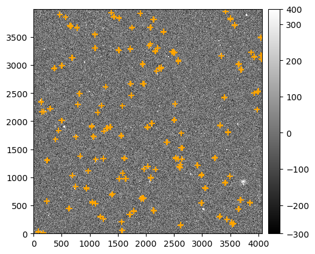

```python
fig = plt.figure()
display = afwDisplay.Display(frame=fig)
display.scale('linear', 'zscale')
display.mtv(my_calexp.image)

xvals = my_sources['deblend_psfCenter_x'].values
yvals = my_sources['deblend_psfCenter_y'].values
with display.Buffering():
    for i in range(len(xvals)):
        if np.isfinite(xvals[i]) & np.isfinite(yvals[i]):
            display.dot('+', xvals[i], yvals[i], size=40, ctype='orange')

plt.show()
```

The preferred method to retrieve catalog data is the TAP service, but as demonstrated above the butler can also be used.